# CapStone: Milestone Report

Santhosh Shankar

March 18, 2016

### OverView

Welcome to Milestone Report - this report deals with textmining and performing some exploratory analysis on the SwiftKey provided data corpus - Blogs, News and Twitter. We will focus mainly on the English Data set and try to do the same on other languages too (if time permits).

### Objectives

Below are the salient features of this report and it’s objectives,

1. Exploratory analysis - perform a thorough exploratory analysis of the data, understanding the distribution of words and relationship between the words in the corpora.
2. Textmining - Understand frequencies of words and word pairs (using nGrams) - build figures and tables to understand variation in the frequencies of words and word pairs in the data.
3. Lay down the foundation for building effective Prediction Algorithm
4. Intent to build a Shiny App that takes as input a phrase (multiple words), one clicks submit, and it predicts the next word using the Prediction Algorithm developed as part of my Project.

The goal of this project is just to display that I’ve gotten used to working with the data and that I am on track to create my prediction algorithm.

### Data Source

The data used for this project has been taken from [SwiftKey](https://d396qusza40orc.cloudfront.net/dsscapstone/dataset/Coursera-SwiftKey.zip).

Your feedback into my work is much appreciated as I am still learning the whole concept of Data Science!!

## Perform Some Exploratary Analysis

```r
    require(knitr)
    opts_chunk$set(message = FALSE, warning = FALSE)
    source("MileStoneReport.R")
    # Initialize
    initialize()

    # Download the data if required
    getCorpusData(pathname)

    # Perform Text Mining on all Language set of files sequentially
    #tdm <- lapply(langs, textMine, pathname)
    # For now, just to Enginlis, "en_US"
    textAnalysisResult <- textMine("en_US", pathname)
    tdm <- textAnalysisResult$tdm
    nGramResult <- textAnalysisResult$myNGrams
```

### Basic Analysis of the Blogs Data

```
## [1] "File Size (in MB):  200.42"
```

```
## [1] "Line Count:  899288"
```

```
## [1] "Word Count:  37546246"
```

```
## [1] "Words Summary Details:"
```

```
##    Min. 1st Qu.  Median    Mean 3rd Qu.    Max.
##    0.00    9.00   28.00   41.75   60.00 6726.00
```

### Basic Analysis of the News Data

```
## [1] "File Size (in MB):  196.28"
```

```
## [1] "Line Count:  1010242"
```

[output not shown]

```
## [1] "Words Summary Details:"
```

```
##    Min. 1st Qu.  Median    Mean 3rd Qu.    Max.
##    1.00   19.00   32.00   34.62   46.00 1123.00
```

### Basic Analysis of the Twitter Data

```
## [1] "File Size (in MB):  159.36"
```

```
## [1] "Line Count:  2360148"
```

```
## [1] "Word Count:  30093369"
```

```
## [1] "Words Summary Details:"
```

```
##    Min. 1st Qu.  Median    Mean 3rd Qu.    Max.
##    1.00    7.00   12.00   12.75   18.00   47.00
```

### Analysis of the Corpus Data from all Files

I have taken 1000 line random samples from each files - blogs, news and twitter text files. And then performed preprocessing and computed n-grams (upto 4) for the sample Corpus.

##### Monogram

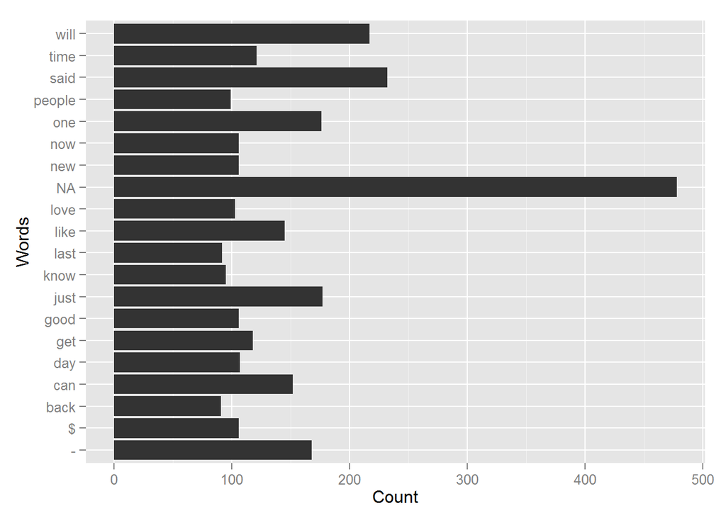

##### Bigram

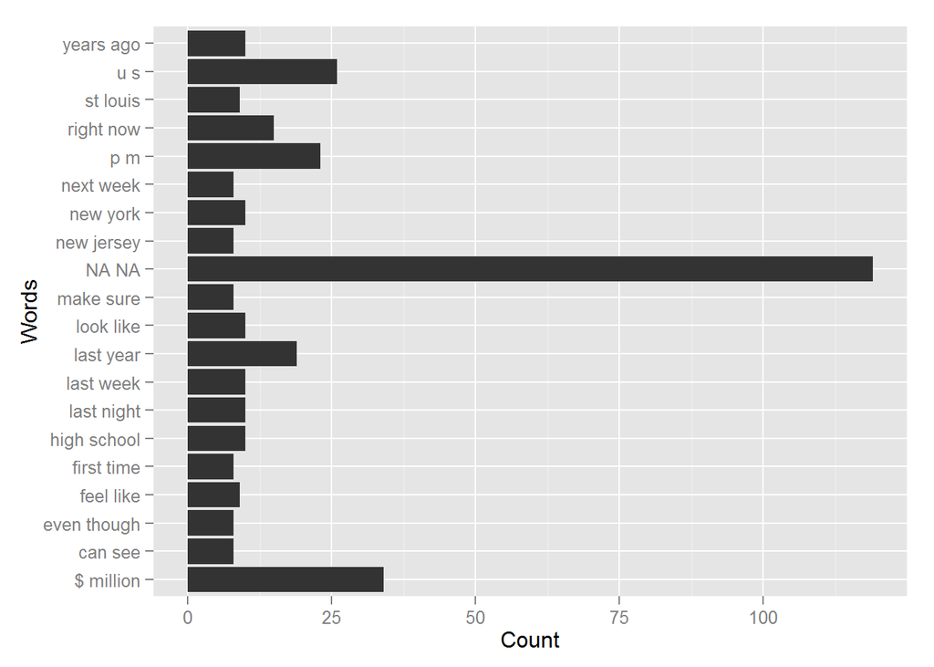

##### Trigram

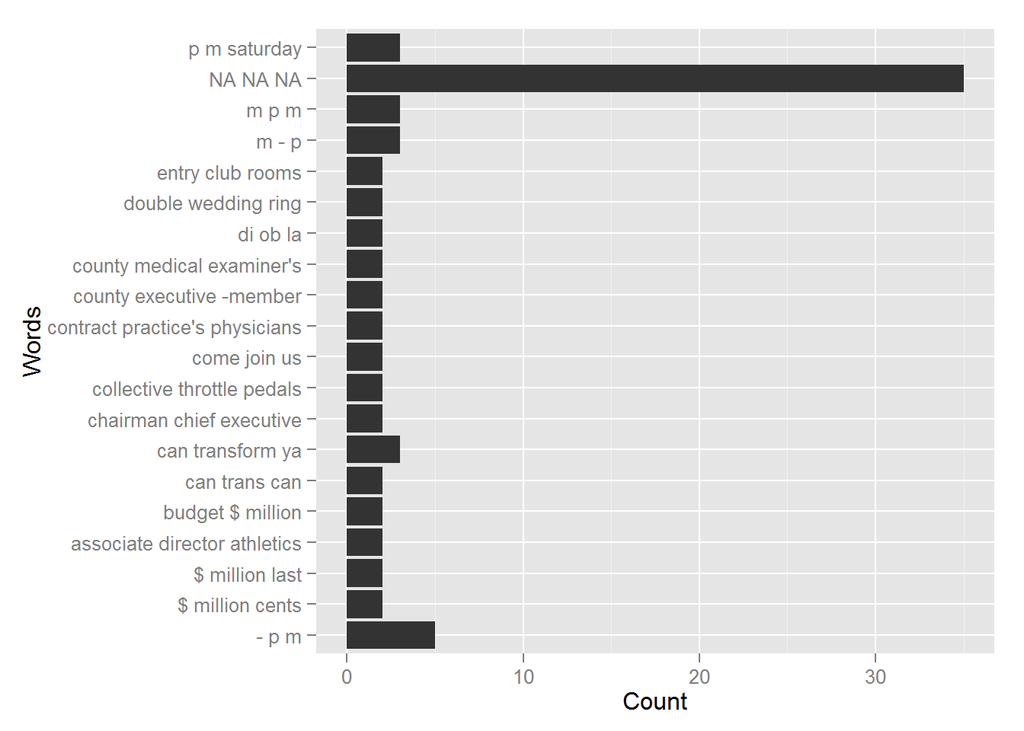

##### Quadraplegram

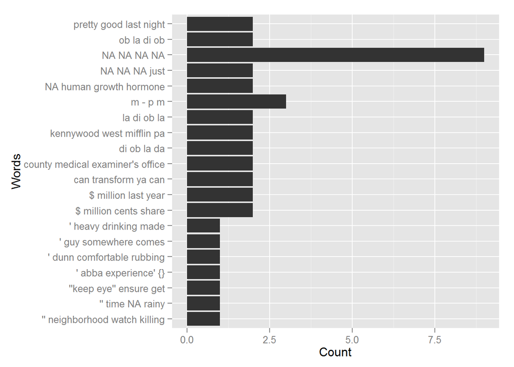

## Next Action Plan

Here are my next Action Plan,

1. Continue to evolv my corpus analysis - cleaning of profanity, increasing sample size to be used for the prediction algorithm.
2. Formulate an optimum prediction algorithm - keeping in mind to balance both memory and run-time efficiency.
3. Implement the prediction algorithm and test on real data for accuracy check.
4. Deploy the prediction algorithm in to a Shiny App to predict the next user input after user keys in a phrase (2-4 words).

# Thank You very Much!!

### Appendix

The source code for my complete analysis (MileStoneReport.R) is available at [My Github Account](https://github.com/HIRIYURS/CapStoneProject/blob/master/MileStoneReport.R)